# Reanalysing Mischel 1972

Simon van Baal

2023-11-15

```r
library(readr)
library(dplyr)
library(tidyr)
library(here)
library(afex)
library(emmeans)
library(rmarkdown)

# for assumption checking
library(DHARMa)
library(performance)

# for plotting
library(broom)
library(ggplot2)
theme_set(theme_light())
```

# Analysis of Simulated Data Based on Mischel (1972)

In this R markdown file, we conduct an analysis of fictional data based on Mischel (1972).

We conduct the same analysis as the originals authors do, conduct assumption checks and consider whether we should perhaps run a different analysis instead.

Use the DHARMa and performance packages for assumption checking.

```r
df <-
  read_csv(here("data/simulated-data_exp1_mischel1972.csv"))
# I want to make sure my factor variable is a factor variable, not a character
# variable.
df <-
  df |>
  mutate(
    condition = factor(condition)
  )

# Setting zero sum contrasts is important, especially for interaction effects.
set_sum_contrasts()
```

```
## setting contr.sum globally: options(contrasts=c('contr.sum', 'contr.poly'))
```

```r
# Chi square test for Mischel et al., 1972
# The assumptions for a chisquare test are very minimal so we can just run this one.

table(df$condition, df$success)
```

```
##
##                   0  1
##   no distraction 10  0
##   think fun       4  6
##   toy             6  4
```

```r
chisquare <-
  chisq.test(df$condition,
             df$success,
             simulate.p.value = T)

chisquare
```

```
##
##  Pearson's Chi-squared test with simulated p-value (based on 2000 replicates)
##
## data:  df$condition and df$success
## X-squared = 8.4, df = NA, p-value = 0.03048
```

The authors also conduct an ANOVA. No information on assumption checks is provided, so we conduct our own.

```r
# The authors also run an ANOVA.

oneWayAnova <-
  aov_ez(id = "id",
    between = "condition",
    dv = "success",
         data = df)

oneWayAnova
```

```
## Anova Table (Type 3 tests)
##
## Response: success
##      Effect    df  MSE      F  ges p.value
## 1 condition 2, 27 0.18 5.25 * .280    .012
## ---
## Signif. codes:  0 '***' 0.001 '**' 0.01 '*' 0.05 '+' 0.1 ' ' 1
```

```r
check_homogeneity(oneWayAnova)
```

[output not shown]

```
## For confidence bands, please install `qqplotr`.
```

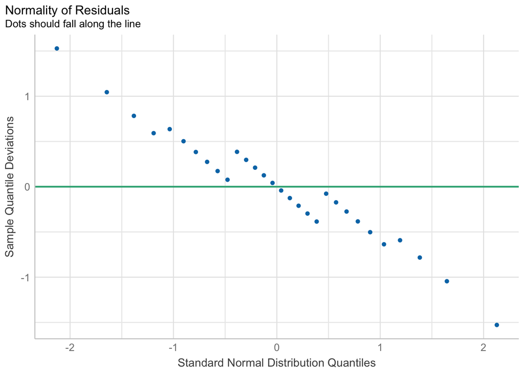

```r
# If you have within-subjects factors, also run:
#check_sphericity(oneWayAnova)

NormalityAovSuccess <-
  check_normality(oneWayAnova)

plot(NormalityAovSuccess, type = 'qq')
```

It is not surprising that the data does not satisfy the assumptions for ANOVA. There cannot be homogeneity of variance across these conditions because in one of the conditions the variance is zero.

```r
contrast_list <-
  list(treatment_v_control = c(-1, .5, .5))

# emmeans will not assume sphericity.
emmAnova <-
  emmeans(oneWayAnova,
          ~ condition)

contrAnova <-
  contrast(emmAnova,
           contrast_list)

contrAnova
```

```
##  contrast            estimate    SE df t.ratio p.value
##  treatment_v_control      0.5 0.163 27   3.062  0.0049
```

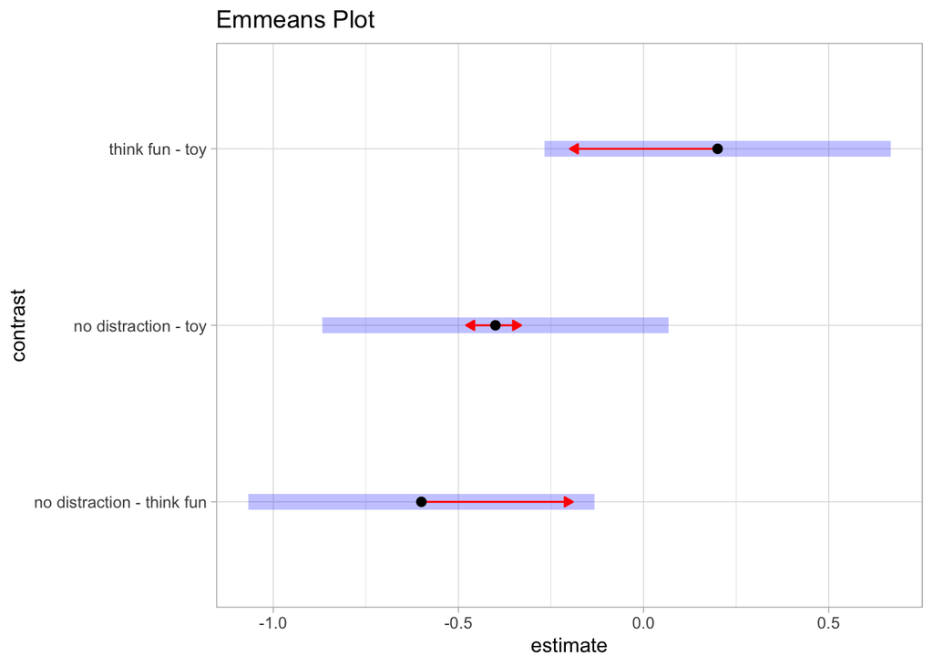

```r
# Here we have a plot with comparison arrows.
plot(pairs(emmAnova),
     comparisons = T) +
  labs(title = "Emmeans Plot")
```

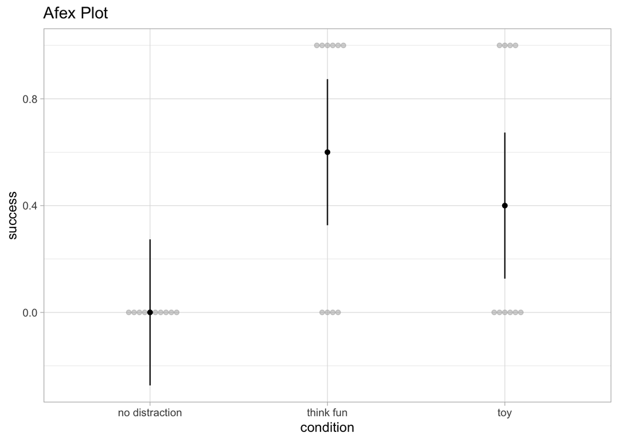

```r
afex_plot(oneWayAnova,
          ~ condition,
          ) +
  labs(title = "Afex Plot")
```

## Linear Models are Equivalent to ANOVAs

Equivalent to an ANOVA, we can run a simple linear model.

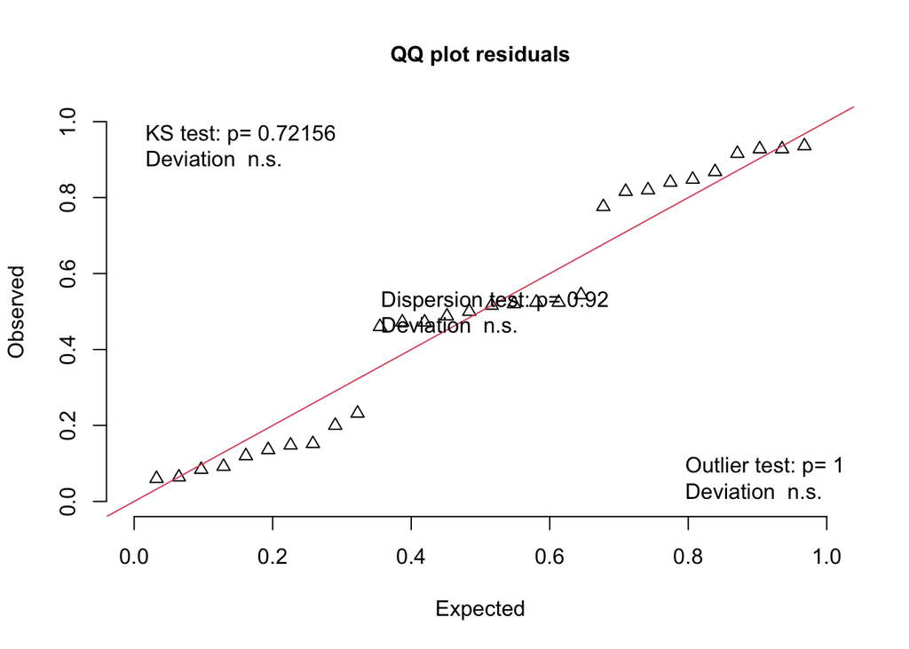

```r
lmSuccess <-
  lm(success ~
       condition,
     data = df)

# We can also run assumption checks for LM because it uses the same method
# as ANOVA
# check_normality(lmSuccess)

# But we can also use DHARMa to extract diagnostic information and do the plots.
diagLmSuccess <-
  simulateResiduals(lmSuccess)

plotQQunif(diagLmSuccess)
```

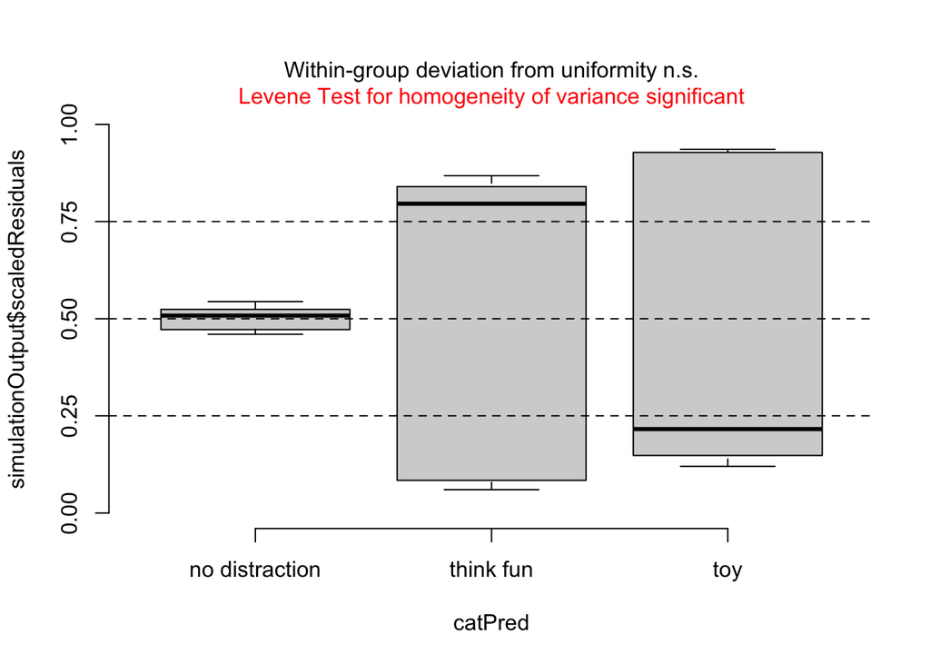

```r
plotResiduals(diagLmSuccess, df$condition, quantreg = T)
```

## If Assumptions are Violated: Consider Why

The successful waiting for the second reward is a typical bernoulli trial. The easiest way to model this is by using a generalised linear model. Contrary to what many people think, these do *not* transform the dependent variable, instead, they use a link function. By default, glm(family = “binomial”) will use a “logit” link - this normally works well.

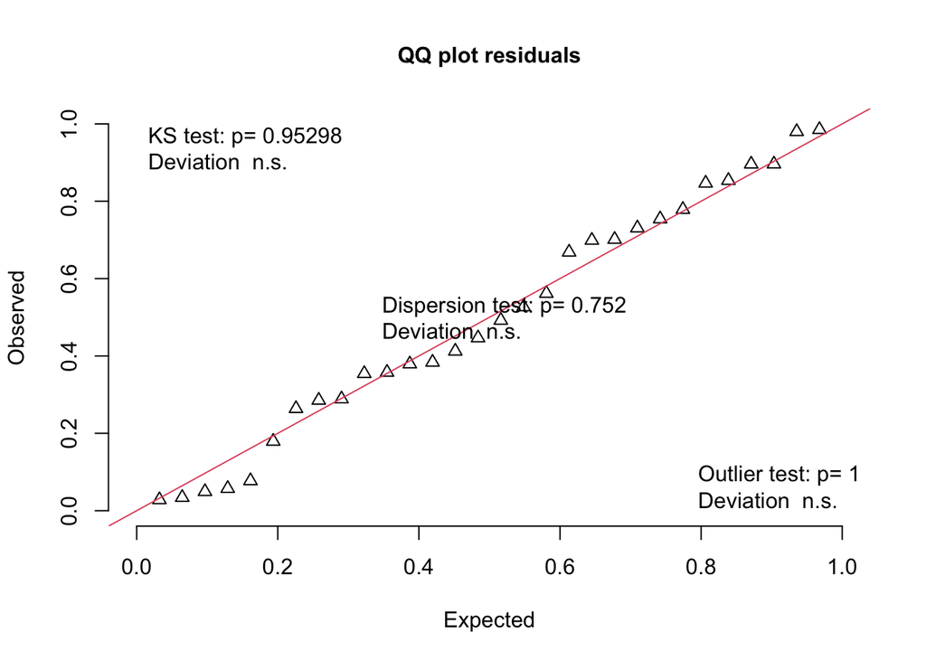

```r
logReg <-
  glm(success ~ condition,
    family = "binomial",
    data = df)

diagLogRegSuccess <-
  simulateResiduals(fittedModel = logReg)

# Normally you can use this function, but I use the two below for the presentation
# plot(diagLogRegSuccess, asFactor = T)

plotQQunif(diagLogRegSuccess)
```

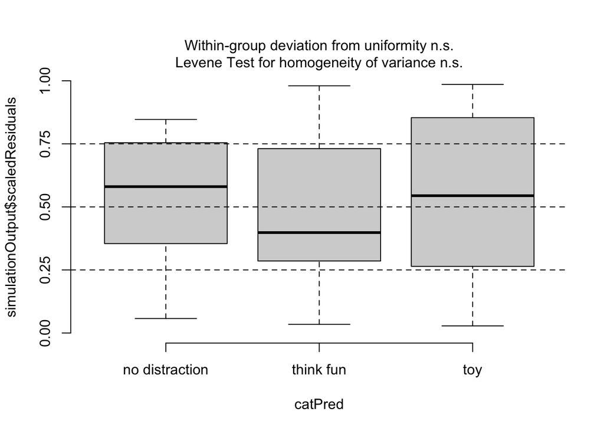

```r
plotResiduals(diagLogRegSuccess, df$condition, quantreg = T)
```

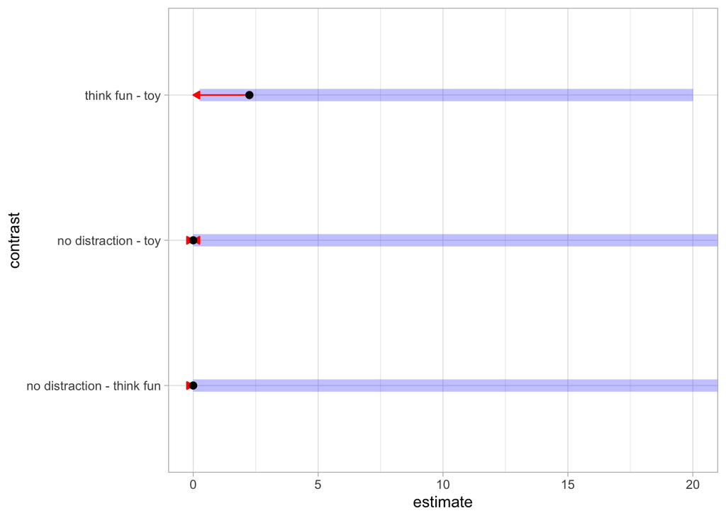

```r
emmLogReg <-
  emmeans(logReg, ~ condition,
        type = "response")

prsLogReg <-
  pairs(emmLogReg, adjust = "fdr")

plot(prsLogReg,
     comparisons = T)
```

In conclusion, apart from the Chi-Square Test being significant (which is not very informative in this case), we have insufficient evidence to conclude that any of these conditions are significantly different from each other. The original experiment used methods that are now considered inappropriate.

It is important to stress, however, that this experiment was conducted more than 50 years ago, and statistical methods back then were less developed than they are now.